# TP_PCR_RIDGE_LASSO_PLS_rendu

Vincent LE MEUR

2024-02-21

# TP R : CR, PLS, Ridge et Lasso

## Compte rendu

On étudi les données des 12 melanges d’essence.

## Expliquer et prédire les composants des mélanges

```r
m0 = lm(y~., data = d) # le . remplace toutes les autres variables dans la base d
summary(m0)
```

```
##
## Call:
## lm(formula = y ~ ., data = d)
##
## Residuals:
##          1          2          3          4          5          6          7
##  1.194e+00 -2.185e-01 -5.383e-01 -7.178e-02  8.210e-01 -3.591e-01 -4.527e-02
##          8          9         10         11         12
##  2.599e-01 -1.665e-15 -2.147e-01  8.882e-16 -8.276e-01
##
## Coefficients:
##              Estimate Std. Error t value Pr(>|t|)
## (Intercept)  118.0637    89.1000   1.325    0.256
## x1          -103.0510   197.5622  -0.522    0.629
## x2           -32.1357    88.8175  -0.362    0.736
## x3            56.7858   481.8556   0.118    0.912
## x4           -40.9381    99.1473  -0.413    0.701
## x5           -30.4938    92.3213  -0.330    0.758
## x6           -17.7700    92.7845  -0.192    0.857
## x7            -0.5656     1.4769  -0.383    0.721
##
## Residual standard error: 0.9182 on 4 degrees of freedom
## Multiple R-squared:  0.9928, Adjusted R-squared:  0.9802
## F-statistic: 78.69 on 7 and 4 DF,  p-value: 0.0004044
```

Un bon $R^2$ mais on à Cependant aucune variable n’est significative ce qui est un signe de multicolinéarité.

```r
acp = PCA(d[,-8], scale=TRUE, graph = FALSE)
print(acp$eig)
```

```
##          eigenvalue percentage of variance cumulative percentage of variance
## comp 1 3.624547e+00           5.177924e+01                          51.77924
## comp 2 1.559255e+00           2.227507e+01                          74.05431
## comp 3 7.813238e-01           1.116177e+01                          85.21608
## comp 4 5.698808e-01           8.141154e+00                          93.35723
## comp 5 4.648069e-01           6.640098e+00                          99.99733
## comp 6 1.497743e-04           2.139632e-03                          99.99947
## comp 7 3.707186e-05           5.295981e-04                         100.00000
```

En effet les 2 dernières composantes sont proches de 0 ce qui peut explique la multicolinéarité

Autre méthode (VIF)

```r
a= vif(m0)


kable(a,caption= "vif")
```

vif

|  | x |
| --- | --- |
| x1 | 4337.350687 |
| x2 | 3935.029998 |
| x3 | 8775.796310 |
| x4 | 6609.344646 |
| x5 | 362.586048 |
| x6 | 9636.008164 |
| x7 | 1.337242 |

On à des valeurs de VIF très élevés ce qui indique une multicolinéarité

## Solution à la multicolinéarité

### StepAIC

```r
m_aic=stepAIC(m0, trace=0) # pas d'affichage du processus de selection
summary(m_aic)
```

```
##
## Call:
## lm(formula = y ~ x1 + x2 + x4 + x5, data = d)
##
## Residuals:
##     Min      1Q  Median      3Q     Max
## -0.8147 -0.2742 -0.1112  0.2329  1.2051
##
## Coefficients:
##             Estimate Std. Error t value Pr(>|t|)
## (Intercept)  100.980      0.749 134.828 3.26e-13 ***
## x1           -40.147      2.990 -13.425 2.98e-06 ***
## x2           -15.152      1.528  -9.918 2.26e-05 ***
## x4           -21.936      1.352 -16.230 8.21e-07 ***
## x5           -12.773      4.866  -2.625   0.0341 *
## ---
## Signif. codes:  0 '***' 0.001 '**' 0.01 '*' 0.05 '.' 0.1 ' ' 1
##
## Residual standard error: 0.716 on 7 degrees of freedom
## Multiple R-squared:  0.9923, Adjusted R-squared:  0.9879
## F-statistic: 226.4 on 4 and 7 DF,  p-value: 1.768e-07
```

On sait que:
$$MSEP : \frac{1}{n}
\sum_{i=1}^{n} (y_i - \hat{y}_i^{(-i)})^{2}$$
et que:
$$RMSEP : \sqrt{MSEP}$$

```r
rmsep=function(fit){
h=lm.influence(fit)$h
return(sqrt(mean((residuals(fit)/(1-h))^2)))
}
rmsep=rmsep(m_aic)
```

Ici on à un RMSEP de 1.2870976 pour le moèle aic

## PCR

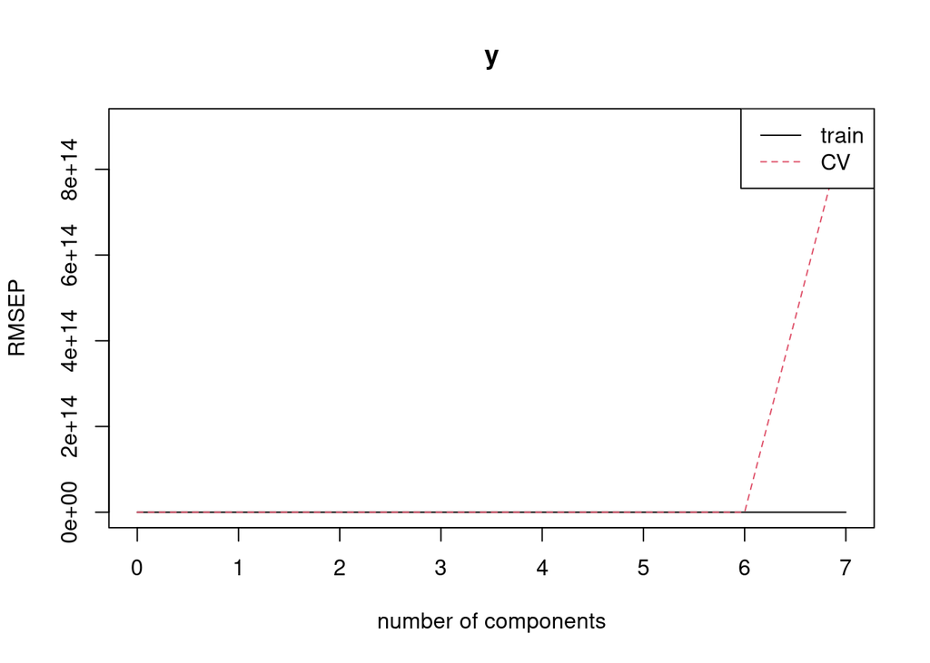

```r
m_pcr=pcr(y~., scale=TRUE, validation="LOO", jackknife = TRUE, data=d)

#Courbe
plot(m_pcr,"validation", estimate = c("train", "CV"), legendpos = "topright")
```

```r
summary(m_pcr)
```

```
## Data:    X dimension: 12 7
##  Y dimension: 12 1
## Fit method: svdpc
## Number of components considered: 7
##
## VALIDATION: RMSEP
## Cross-validated using 12 leave-one-out segments.
##        (Intercept)  1 comps  2 comps  3 comps  4 comps  5 comps  6 comps
## CV           6.811   10.386    9.188    8.878    8.014    9.056    6.347
## adjCV        6.811    9.961    8.828    8.524    7.741    8.674    6.082
##          7 comps
## CV     9.052e+14
## adjCV  8.666e+14
##
## TRAINING: % variance explained
##    1 comps  2 comps  3 comps  4 comps  5 comps  6 comps  7 comps
## X    51.78    74.05    85.22    93.36   100.00   100.00   100.00
## y    88.03    88.91    92.92    93.46    99.21    99.28    99.28
```

On choisira donc 6 composantes qui nous assure un RMSEP = 6.347.

Voici les prédictions graphiquement (obtenues par validation croisée) :

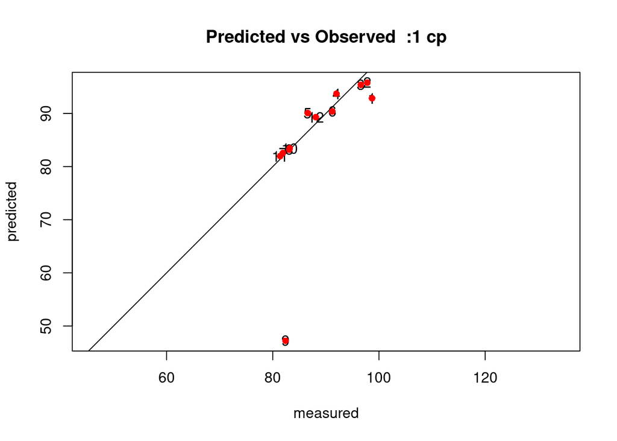

```r
obsfit = predplot(m_pcr, ncomp=1, which = "validation", asp=1,line=TRUE, main="Predicted vs Observed  :1 cp",label= rownames(d))
points(obsfit, pch=16, col="red")
```

```r
obsfit
```

```
##    measured predicted
## 1      98.7  92.85945
## 2      97.8  95.79921
## 3      96.6  95.39032
## 4      92.0  93.70906
## 5      86.6  90.08335
## 6      91.2  90.38403
## 7      81.9  82.55370
## 8      83.1  83.17987
## 9      82.4  47.22969
## 10     83.2  83.46409
## 11     81.4  81.98313
## 12     88.1  89.30184
```

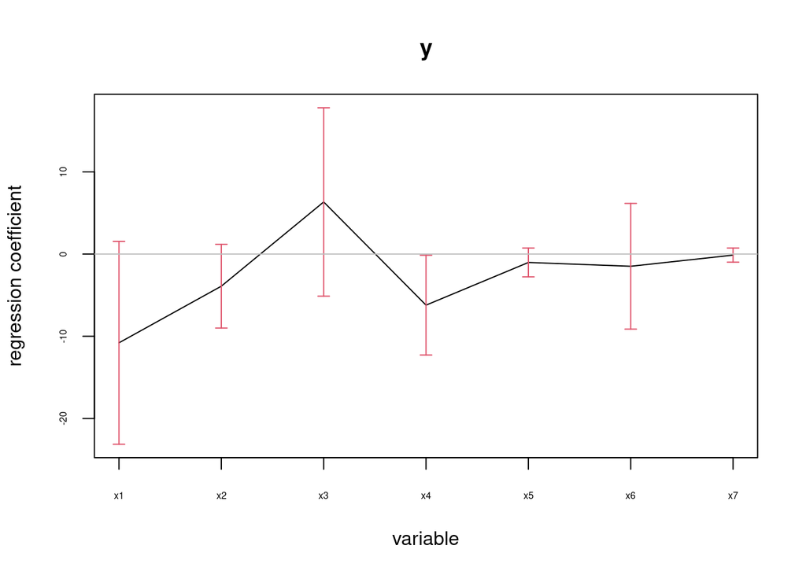

```r
#Les coefficients et leur significativité est obtenue avec :
coefplot(m_pcr, ncomp=6, se.whiskers = TRUE, labels = prednames(m_pcr), cex.axis = 0.5)
```

```r
jack.test(m_pcr, ncomp=6)
```

```
## Response y (6 comps):
##     Estimate Std. Error Df t value Pr(>|t|)
## x1 -10.79424   12.34183 11 -0.8746   0.4005
## x2  -3.90361    5.09517 11 -0.7661   0.4597
## x3   6.34123   11.46112 11  0.5533   0.5911
## x4  -6.21160    6.06616 11 -1.0240   0.3278
## x5  -1.02022    1.75386 11 -0.5817   0.5725
## x6  -1.48218    7.64820 11 -0.1938   0.8499
## x7  -0.12482    0.85860 11 -0.1454   0.8870
```

```r
#L’intercept est obtenu avec :

coef(m_pcr, ncomp=6, intercept=TRUE)
```

```
## , , 6 comps
##
##                       y
## (Intercept) 105.8575544
## x1          -10.7942408
## x2           -3.9036118
## x3            6.3412326
## x4           -6.2115996
## x5           -1.0202197
## x6           -1.4821760
## x7           -0.1248161
```

Ces coefficents sont cependant ceux obtenus avec les variables réduites (mais pas centrées), car ACP normée au départ. Les coefficients des variables d’origine sont donc

```r
sds = apply(d,2, "sd" ) # calcul des ecart-types de chaque variable
a=coef(m_pcr, ncomp=6, intercept=TRUE)/sds[-8] #pour avoir les coefs des variables d'origine

a
```

```
## , , 6 comps
##
##                       y
## (Intercept) 1147.011353
## x1           -55.204060
## x2           -72.526154
## x3            27.933771
## x4          -108.781311
## x5            -3.483173
## x6            -6.837650
## x7            -1.352436
```

Le modèle de régression obtenu est donc :

$$y = 1147.0113533 -55.20406
x1 -72.5261543 x2 + 27.9337707 x3 -108.781311 x4 -3.4831725
x5 -6.8376498 x6 + -1.3524357 x7 + erreur$$

L’essence 3 a des coéfficients positifs donc plus il est présent plus l’indice d’octane moteur est élevé

### Prédiction PLS

```
## Data:    X dimension: 12 7
##  Y dimension: 12 1
## Fit method: kernelpls
## Number of components considered: 7
##
## VALIDATION: RMSEP
## Cross-validated using 12 leave-one-out segments.
##        (Intercept)  1 comps  2 comps  3 comps  4 comps  5 comps  6 comps
## CV           6.811    9.639    6.454    7.090    6.599    9.044    6.359
## adjCV        6.811    9.246    6.180    6.791    6.322    8.662    6.093
##          7 comps
## CV     3.966e+12
## adjCV  3.797e+12
##
## TRAINING: % variance explained
##    1 comps  2 comps  3 comps  4 comps  5 comps  6 comps  7 comps
## X    51.58    63.89    81.49    91.88   100.00   100.00   100.00
## y    91.73    98.23    99.06    99.21    99.21    99.28    99.28
```

On a un RMSEP de 6.359

#### RIDGE regression

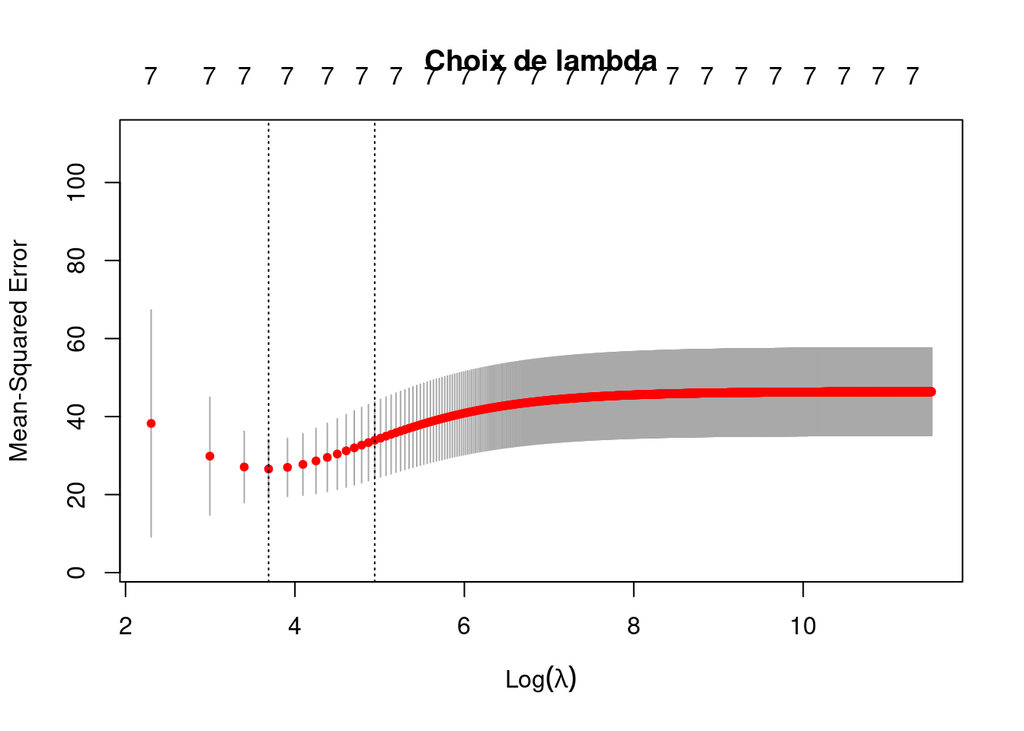

On trouve la valeur optimale : lambda_optimal=40 pour laquelle on obtient une MSEP égale à 26.5682908 ce qui correspond à un RMSEP = sqrt(MSEP) = 5.1544438

### LASSO

On fait la même chose que pour Ridge en prenant $\alpha$=1

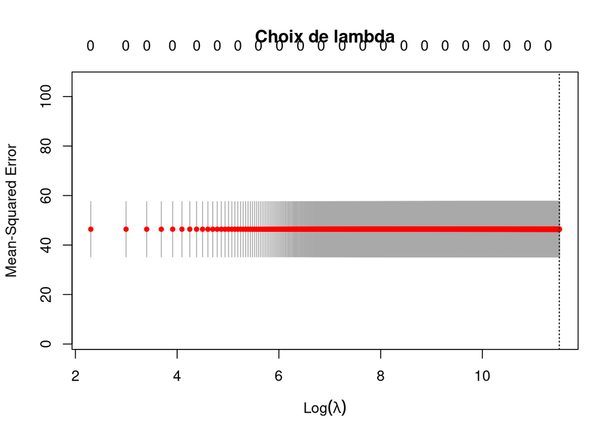

```
## [1] 99890
```

```
## 8 x 1 sparse Matrix of class "dgCMatrix"
##                   s0
## (Intercept) 88.58333
## x1           0.00000
## x2           .
## x3           .
## x4           .
## x5           .
## x6           .
## x7           .
```

On trouve la valeur optimale : lambda_optimal=9.989^{4} pour laquelle on obtient une MSEP égale à 46.3930579 ce qui correspond à un RMSEP = sqrt(MSEP) = 6.811245

## Conclusion:

RMSEP pour différentes méthodes

| Méthode | RMSEP |
| --- | --- |
| StepAIC | 1.287098 |
| ACR | 6.347000 |
| PLS | 6.359000 |
| RIDGE | 5.154444 |
| Lasso | 6.811245 |